# Case Study 2

Jules Stacy

March 3, 2020

#Attrition and Salary Predictions using Regression and Machine Learning

This project attempts to answer two questions: 1. Given a variety of factors, how likely is it for any given employee to leave their current company? And can we predict this? 2. Given a variety of factors, are we able to predict a given employee’s salary?

There are three datasets provided: CaseStudy2-data.csv: A large selection of observations with all data included CaseStudy2CompSet No Salary.csv: 300 observations with all data except for MonthlyIncome CaseStudy2CompSet No Attrition.csv: 300 observations with all data except for Attrition

Finally, some observations drawn from the data will be provided as additional analysis.

All code used for analysis is included in this document, and all data and files will be made available in the git repository located at: https://github.com/jules-stacy/CaseStudy2DDS.git

A video presentation on this project can be found at: https://youtu.be/QGepj42kPbs

Load Libraries

```r
invisible(library(tidyverse))
invisible(library(caret))
invisible(library(class))
invisible(library(dummies))
invisible(library(e1071))
invisible(library(MASS))
invisible(library(ggplot2))
invisible(library(GGally))
```

Import Data

```r
#setwd(dirname(rstudioapi::getActiveDocumentContext()$path))
train = read.csv("./Data/CaseStudy2-data.csv")
comps = read.csv("./Data/CaseStudy2CompSet No Salary.csv")
compa = read.csv("./Data/CaseStudy2CompSet No Attrition.csv")
```

NA and Levels Check

```r
#check for NA values
#sum(is.na(train))
#sum(is.na(comps))
#sum(is.na(compa))

#Data seems to be clean of NA values. Checking some levels
#names(train)
#levels(train$Attrition)
#levels(train$Department)
#levels(train$EducationField)
#levels(train$JobRole)
#levels(train$MaritalStatus)
#levels(train$BusinessTravel)

#levels(comps$Attrition)
#levels(comps$Department)
#levels(comps$EducationField)
#levels(comps$JobRole)
#levels(comps$MaritalStatus)
#levels(comps$BusinessTravel)

#levels(compa$Department)
#levels(compa$EducationField)
#levels(compa$JobRole)
#levels(compa$MaritalStatus)
#levels(compa$BusinessTravel)
```

Upon further review of the data, there is some additional setup that needs to be done. There are a number of categorical variables with ratings from 1 to 4 that need to be set as factors. And for screening tests there need to be two lists, one for factors and another for numerics. Finally there are three junk variables which feature a single column of one repeated value, which need to be removed.

Factor Setting, begin data cleaning

```r
#Getting data for Attrition Prediction
colnames(comps)[1] <- "ID"
attrition_train <- merge(train, comps, all=TRUE)


inputdata=attrition_train
#Data was pre-cleaned, missing monthly income values from comps set
#iterate through variable names to set factors
for(i in 1:length(names(inputdata))){
  varb=names(inputdata[i])
  #set factor variables based on character
  if(!is.numeric(inputdata[3, varb])){
    inputdata[,varb] <- as.factor(inputdata[,varb])
  }
}

drop <- c("EmployeeCount", "StandardHours", "Over18")
inputdata <- inputdata[,!(names(inputdata) %in% drop)]

inputdata$PerformanceRating <- as.factor(inputdata$PerformanceRating)
inputdata$Education <- as.factor(inputdata$Education)
inputdata$EnvironmentSatisfaction <- as.factor(inputdata$EnvironmentSatisfaction)
inputdata$JobInvolvement <- as.factor(inputdata$JobInvolvement)
inputdata$JobSatisfaction <- as.factor(inputdata$JobSatisfaction)
inputdata$RelationshipSatisfaction <- as.factor(inputdata$RelationshipSatisfaction)
inputdata$StockOptionLevel <- as.factor(inputdata$StockOptionLevel)
inputdata$WorkLifeBalance <- as.factor(inputdata$WorkLifeBalance)

#Debugging Block
factor_check <- lapply(inputdata, is.factor)
factor_logic <- as.logical(factor_check)
factor_numeric <- !factor_logic
trainfactors <- inputdata[,factor_logic]
trainnumerics <- inputdata[,factor_numeric]
factor_vars<- names(trainfactors)
numeric_vars <- names(trainnumerics)

#adjust for over-representation
#Because of the number of no vs. yes responses from attrition, we must resample our data to eliminate bias posed by over-representation from "no" cases.
invisible(sum(inputdata$Attrition=="No")) #979 cases
invisible(sum(inputdata$Attrition=="Yes")) #191 cases
no_attr <- inputdata[inputdata$Attrition=="No",]
yes_attr <- inputdata[inputdata$Attrition=="Yes",]
no_attr <- no_attr[sample(nrow(no_attr), size=191),]
inputdata <- merge(no_attr, yes_attr, all=TRUE)


#Create dataframe with all encoded dummy variables
invisible(dummy.df <- dummy.data.frame(inputdata, sep = "."))
dummy.df$Attrition <- inputdata$Attrition
```

Because there were 979 cases were there was no attrition and 191 cases where there was attrition, the no cases were over-represented in the dataset. As a result the data had to be randomly resampled to balance the number of no and yes cases. The end result is a dataset with 382 observations, half of which are yes cases.

With a total of 32 variables, it is time to narrow down which variables we will look at. KNN does not do well with a large number of predictor variables. And Naive Bayes assumes independence from variable to variable despite there being variables that are potentially related in this dataset. Further complicating this, there was at least one nominal categorical variable that had to be recoded. Thus, a dataframe containing individual variables for each nominal category had to be created, bringing the total number of independent variables up to 76.

For efficiency, the variables will be narrowed down. Since categorical variables feature heavily in this analysis, a chi-square test will be run for ever comparison to Attrition Rate, and variable relationships will be screened out based on p-values. A reference level of alpha=0.05 will be used.

Variable Selection: First Screening

```r
#narrow down variables with Chi-Squared and Phi Correlation
#initialize vectors
p.list <- c()
var.list<- c()
phi.list<- c()
sig.list <- c()

#set the threshold for variable inclusion
alpha <- 0.05

#Perform AOV on numeric variables vs. attrition rate
for(i in 1:(length(names(dummy.df)))){

  #build a temporary model
  Xsq <- invisible(chisq.test(dummy.df$Attrition, dummy.df[,i]))
  #fetch the p-value
  pval <- Xsq$p.value
  Xsq.stat <- Xsq$statistic

  #build list of variables based on p-value threshold
  #also calculate the phi coefficient for effect size
  if(pval < alpha){
    sig.list <- c(sig.list, names(dummy.df[i]))
    phi.stat <- sqrt(Xsq.stat/nrow(dummy.df))

    if(phi.stat > 0.25){
      phi.list <- c(phi.list, phi.stat)
      p.list <- c(p.list, format(pval))
      var.list <- c(var.list, names(dummy.df[i]))
    }

  }
}



#Display data, Remove Attrition from Variable List
var.list
```

```
##  [1] "Age"                  "Attrition.No"         "Attrition.Yes"
##  [4] "JobLevel"             "OverTime.No"          "OverTime.Yes"
##  [7] "StockOptionLevel.0"   "YearsInCurrentRole"   "YearsWithCurrManager"
## [10] "Attrition"
```

```r
p.list
```

```
##  [1] "0.01914737"   "3.373773e-84" "3.373773e-84" "8.55005e-06"
##  [5] "3.408214e-10" "3.408214e-10" "5.17544e-07"  "0.01000999"
##  [9] "0.004031249"  "3.373773e-84"
```

```r
unname(phi.list)
```

```
##  [1] 0.4024732 0.9947644 0.9947644 0.2746174 0.3212601 0.3212601 0.2568298
##  [8] 0.2894144 0.2960300 0.9947644
```

```r
#build variable lists for plotting and analysis
skiplist <- c("Attrition", "Attrition.No", "Attrition.Yes", "OverTime.No")
sig.list <- sig.list[!sig.list %in% skiplist]
var.list <- var.list[!var.list %in% skiplist]
```

These have been selected based on a cutoff of 0.25. This number was selected to be relatively high in the range of phi correlation values while allowing enough variables for modeling.

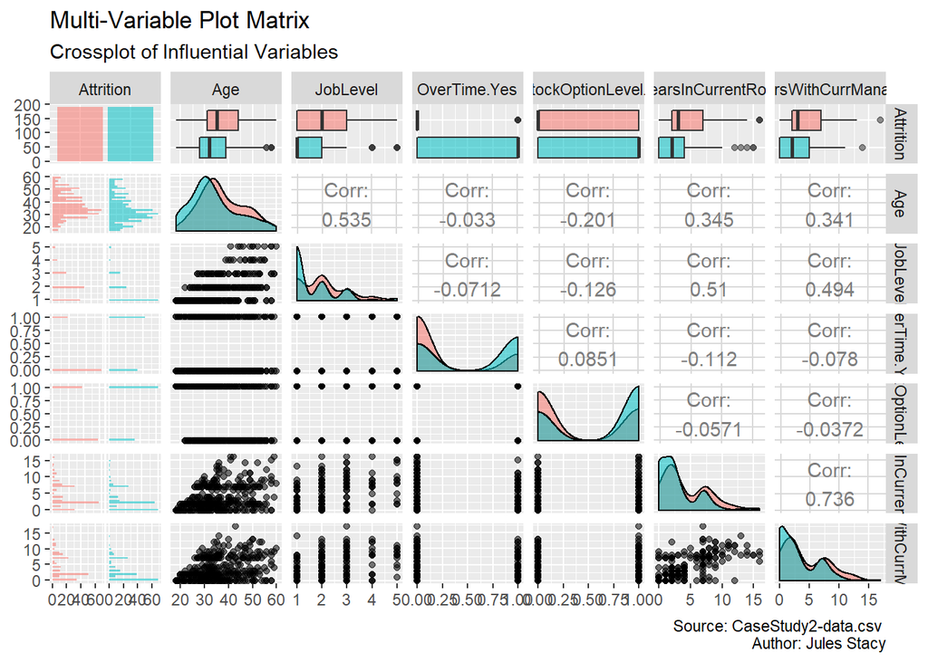

The graph is arranged so that Attrition is both the first row and first column. People who leave their jobs are represented by the green colors on the graph, and people who don’t leave their jobs are represented by red colors on the graph.

```r
normalize.df <- dummy.df[,c("Attrition", var.list)]

#normalize data: all data falls between zero and one to remove bias from large numbers
for(i in names(normalize.df)){
  tempcol <- as.double(normalize.df[,i]) #some of them wanted to stay factors
  tempcol <- as.numeric(tempcol) #this is redundant but it works the way I want
  normalize.df[,i]<- (tempcol-min(tempcol))/(max(tempcol)-min(tempcol))
  }

#Attrition Column: 0=No, 1=Yes
```

The chosen variables will be tested using K-nearest-neighbor testing to predict classifications for a set of points for whom Attrition is unknown.

K-nearest Neighbor testing is a method of predicting outcomes where a sample is compared to k number of its nearest neighbors, and the most prolific scenario of that group is then chosen as the category for the sample. For example, a sample point will be chosen and 5 nearest neighbors will be compared to see if there are more “Yes” or “No” responses among the neighbors; if there are more “Yes” responses, the sample point will be classified as “Yes.”

Train-and-test testing is a method where a dataset of known responses is randomly divided into a training set upon which a model is built, and then that model is validated on the test set before full deployment on a set where responses are not known.

Leave-one-out testing is a method where a dataset of known responses is tested one at a time against itself, and validated internally before full deployment on a set where responses are not known.

The first step is determining the optimal number of comparison neighbors, which will be determined using hyperparameter testing (or, average accuracies over a lot of loops).

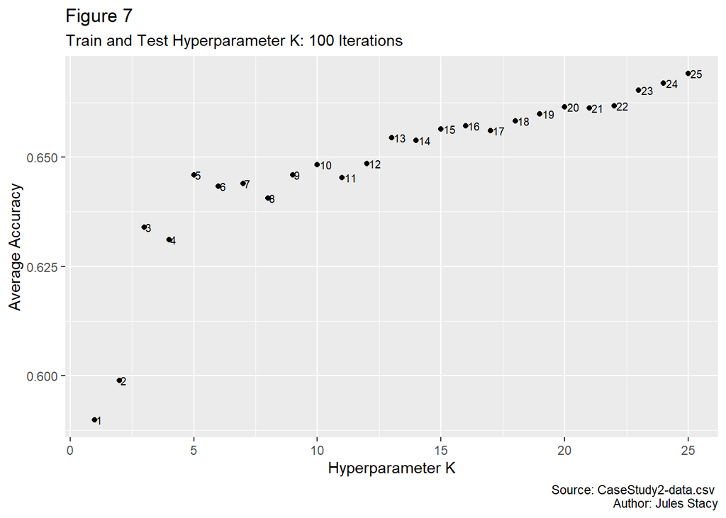

```r
#dataframe for analysis
#Arrange your dataframe so the response variable is in column one
k.data <- normalize.df

#define some other variables before running the loops
kmax=25
loops=100


#Preallocated dataframes and other indicators
accs1 = data.frame(k = numeric(kmax), accuracy = numeric(kmax), accuracy2=numeric(kmax))
accs2 = data.frame(k = numeric(kmax), accuracy = numeric(kmax), accuracy2=numeric(kmax))
ncolumn<- length(k.data)

#time to determine optimal k values

#-----define loop-----
#housed processes to speed compile time
#each loop processes train vs test and then icv
for(j in 1:loops){
  train.k <- k.data[sample(nrow(k.data), size=(nrow(k.data)*(2/3))),]
  test.k <- setdiff(k.data, train.k)
for(i in 1:kmax)
{
  #KNN using train and test sets
  classifications1 = knn(train.k[,c(2:ncolumn)],test.k[,c(2:ncolumn)],train.k[,1], prob = TRUE, k = i)
  #results table
  sur1 = table(test.k[,1],classifications1)
  #confusion matrix
  CM1 = confusionMatrix(sur1)
  accs1$accuracy[i] = accs1$accuracy[i] + CM1$overall[1]
  accs1$k[i] = i

  #KNN using leave-one-out analysis
  classifications2 = knn.cv(k.data[,c(2:ncolumn)], k.data[,1], prob=TRUE, k=i)
  #results table
  sur2 = table(k.data[,1],classifications2)
  #confusion matrix
  CM2 = confusionMatrix(sur2)
  accs2$accuracy[i] = accs2$accuracy[i] + CM2$overall[1]
  accs2$k[i] = i

  }
}

#finish the calculation of averages
accs1$accuracy <- accs1$accuracy/loops
accs2$accuracy <- accs2$accuracy/loops

#-----build plots-----
p3 <- ggplot(data=accs1, aes(x=k, y=accuracy)) +
  geom_point() +
  geom_text(aes(label=accs1$k), hjust=-.2, size=2.7)+
  labs(title = "Figure 7",
       subtitle = "Train and Test Hyperparameter K: 100 Iterations",
       caption = "Source: CaseStudy2-data.csv \nAuthor: Jules Stacy",
       x = "Hyperparameter K",
       y = "Average Accuracy")

p4 <- ggplot(data=accs2, aes(x=k, y=accuracy)) +
  geom_point() +
  geom_text(aes(label=accs2$k), hjust=-.2, size=2.7)+
  labs(title = "Figure 8",
       subtitle = "Leave One Out Hyperparameter K: 100 Iterations",
       caption = "Source: CaseStudy2-data.csv \nAuthor: Jules Stacy",
       x = "Hyperparameter K",
       y = "Average Accuracy")


p3
```

The above graphic displays a graph of hyperparameter k-values for the purposes of choosing the most optimal k-value for testing. This graph was generated based on 100 sets of randomly generated train and test data.

Because train and test sets are randomized every time this chunk of code is run, accuracy values may have changed and another k-value may make more contextual sense; however as of the time of this analysis, k=13 has a decently high accuracy at greater than 64% while not having too many datapoints to cause overfitting and while being an odd number.

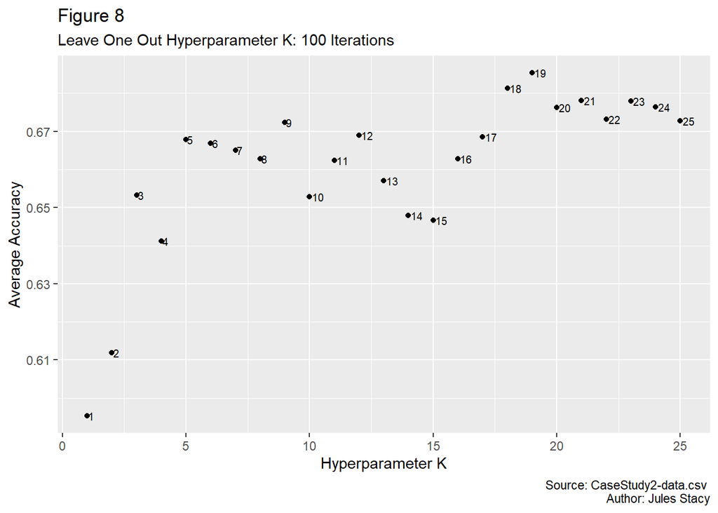

The above graphic is a graph of hyperparameter k-values for the purpose of choosing the most optimal k-value for testing. This graph was generated based on 100 sets of leave-one-out k-nearest-neighbor tests on the entire initial training set.

Because train and test sets are randomized every time this chunk of code is run, accuracy values may have changed and another k-value may make more contextual sense; however as of the time of this analysis, k=13 has a decently high accuracy at approximately 65% while not having too many datapoints to cause overfitting and while being an odd number.

```r
#define k-values and possibly other variables
k1=13
k2=13
train.k <- k.data[sample(nrow(k.data), size=(nrow(k.data)*(2/3))),]
test.k <- setdiff(k.data, train.k)


#code for test and train
  knn_tnt = knn(train.k[,c(2:ncolumn)],test.k[,c(2:ncolumn)],train.k[,1], prob = TRUE, k = k1)
  #results table
  sur1 = table(test.k[,1],knn_tnt)
  #confusion matrix
  CM1 = confusionMatrix(sur1)

#code for leave one out
  knn_loo = knn.cv(k.data[,c(2:ncolumn)], k.data[,1], prob=TRUE, k=k2)
  #results table
  sur2 = table(k.data[,1],knn_loo)
  #confusion matrix
  CM2 = confusionMatrix(sur2)
```

```
## Confusion Matrix and Statistics
##
##    knn_tnt
##      0  1
##   0 41 20
##   1 22 33
##
##                Accuracy : 0.6379
##                  95% CI : (0.5435, 0.7251)
##     No Information Rate : 0.5431
##     P-Value [Acc > NIR] : 0.02448
##
##                   Kappa : 0.2726
##
##  Mcnemar's Test P-Value : 0.87737
##
##             Sensitivity : 0.6508
##             Specificity : 0.6226
##          Pos Pred Value : 0.6721
##          Neg Pred Value : 0.6000
##              Prevalence : 0.5431
##          Detection Rate : 0.3534
##    Detection Prevalence : 0.5259
##       Balanced Accuracy : 0.6367
##
##        'Positive' Class : 0
##
```

Above is the result of the train-and-test knn process.

```
## Confusion Matrix and Statistics
##
##    knn_loo
##       0   1
##   0 131  60
##   1  71 120
##
##                Accuracy : 0.6571
##                  95% CI : (0.6071, 0.7046)
##     No Information Rate : 0.5288
##     P-Value [Acc > NIR] : 2.557e-07
##
##                   Kappa : 0.3141
##
##  Mcnemar's Test P-Value : 0.3823
##
##             Sensitivity : 0.6485
##             Specificity : 0.6667
##          Pos Pred Value : 0.6859
##          Neg Pred Value : 0.6283
##              Prevalence : 0.5288
##          Detection Rate : 0.3429
##    Detection Prevalence : 0.5000
##       Balanced Accuracy : 0.6576
##
##        'Positive' Class : 0
##
```

Below, the knn model is fitted to the competition data using combined train and test data from above, and attrition is predicted for each individual. This process is similar to a mesh of the above two methods, where leave-one-out is run on the combined train and test from above, and then the competition set is plugged in as the test data set.

```r
#==========Prep competition:attrition dataset for predictions==============
#Data was pre-cleaned, no NA values
#iterate through variable names to set factors
inputdata=compa
for(i in 1:length(names(inputdata))){
  varb=names(inputdata[i])
  #set factor variables based on character
  if(!is.numeric(inputdata[3, varb])){
    inputdata[,varb] <- as.factor(inputdata[,varb])
  }
}

drop <- c("EmployeeCount", "StandardHours", "Over18") #vars with one level
inputdata <- inputdata[,!(names(inputdata) %in% drop)]

#set factors
inputdata$PerformanceRating <- as.factor(inputdata$PerformanceRating)
inputdata$Education <- as.factor(inputdata$Education)
inputdata$EnvironmentSatisfaction <- as.factor(inputdata$EnvironmentSatisfaction)
inputdata$JobInvolvement <- as.factor(inputdata$JobInvolvement)
inputdata$JobSatisfaction <- as.factor(inputdata$JobSatisfaction)
inputdata$RelationshipSatisfaction <- as.factor(inputdata$RelationshipSatisfaction)
inputdata$StockOptionLevel <- as.factor(inputdata$StockOptionLevel)
inputdata$WorkLifeBalance <- as.factor(inputdata$WorkLifeBalance)

#Create dataframe with all encoded dummy variables
invisible(dummy.df <- dummy.data.frame(inputdata, sep = "."))
#no Attrition in compa set


#================normalize data============
#specify variables for selection
normalize.df <- dummy.df[,var.list]

#normalize data: all data falls between zero and one to remove bias from large numbers
for(i in names(normalize.df)){
  tempcol <- as.double(normalize.df[,i]) #some of them wanted to stay factors
  tempcol <- as.numeric(tempcol) #this is redundant but it works the way I want
  normalize.df[,i]<- (tempcol-min(tempcol))/(max(tempcol)-min(tempcol))
  }


#===========Predict using model 2 (leave one out)====================
ncolumn2<- length(k.data)
results = knn(k.data[,c(2:ncolumn2)],normalize.df,k.data$Attrition, prob = TRUE, k = 13)

#===========Package and ship it=======================
predict <- as.data.frame(results)
predict$ID <- compa$ID                #add ID column
predict <- predict[,c(2,1)]           #reorder columns
colnames(predict)[2] <- "Attrition"   #rename prediction column
#Attrition Column: 0=No, 1=Yes
levels(predict$Attrition) <- c("No", "Yes") #fix levels
#write.csv(predict, "./Data/Case2PredictionsStacy Attrition.csv")
```

# ================================================================================

# ================================================================================

Problem 2: What factors predict the salaries of employees?

First a dataframe is built where all available salary information is included and a dummy dataframe is generated. This allows separation of employees by job role, department, business travel, and other factors.

```r
#Getting data for Salary Prediction
salary_train <- merge(train, compa, all=TRUE)
inputdata <- salary_train

#Data was pre-cleaned, missing monthly income values from comps set
#iterate through variable names to set factors
for(i in 1:length(names(inputdata))){
  varb=names(inputdata[i])
  #set factor variables based on character
  if(!is.numeric(inputdata[3, varb])){
    inputdata[,varb] <- as.factor(inputdata[,varb])
  }
}

drop <- c("EmployeeCount", "StandardHours", "Over18")
inputdata <- inputdata[,!(names(inputdata) %in% drop)]

inputdata$PerformanceRating <- as.factor(inputdata$PerformanceRating)
inputdata$Education <- as.factor(inputdata$Education)
inputdata$EnvironmentSatisfaction <- as.factor(inputdata$EnvironmentSatisfaction)
inputdata$JobInvolvement <- as.factor(inputdata$JobInvolvement)
inputdata$JobSatisfaction <- as.factor(inputdata$JobSatisfaction)
inputdata$RelationshipSatisfaction <- as.factor(inputdata$RelationshipSatisfaction)
inputdata$StockOptionLevel <- as.factor(inputdata$StockOptionLevel)
inputdata$WorkLifeBalance <- as.factor(inputdata$WorkLifeBalance)

#Debugging Block
factor_check <- lapply(inputdata, is.factor)
factor_logic <- as.logical(factor_check)
factor_numeric <- !factor_logic
trainfactors <- inputdata[,factor_logic]
trainnumerics <- inputdata[,factor_numeric]
factor_vars<- names(trainfactors)
numeric_vars <- names(trainnumerics)


#Create dataframe with all encoded dummy variables
invisible(dummy.df <- dummy.data.frame(inputdata, sep = "."))
```

With more than 70 variables available for analysis we must narrow it down.

Variables will first be screened out using p-value:

```r
#selection of variables for salary regression
#narrow down variables with Chi-Squared and Phi Correlation
#Set target variable
#initialize vectors
p.list <- c()
var.list<- c()
arsq.list<- c()
sig.list <- c()

#set the threshold for variable inclusion
alpha <- 0.05
threshold.adj.r <- 0.1

#Perform AOV on numeric variables vs. attrition rate
for(i in 2:(length(names(dummy.df)))){
  #~~~Adj-R-Squared using LM~~~
  #build a temporary model
  linmod <- lm(MonthlyIncome~dummy.df[,i], data=dummy.df)
  #grab adj rsq
  arsq <- summary(linmod)$adj.r.squared
  pval <- summary(linmod)$coefficients[8]


  #build list of variables based on p-val and adj rsq threshold
  #also calculate the phi coefficient for effect size
  if(pval < alpha){
    sig.list <- c(sig.list, names(dummy.df[i]))
    if(arsq > threshold.adj.r){
      arsq.list <- c(arsq.list, arsq)
      p.list <- c(p.list, format(pval))
      var.list <- c(var.list, names(dummy.df[i]))
    }

  }
}



#Display data, Remove Attrition from Variable List
var.list
```

```
##  [1] "Age"                           "JobLevel"
##  [3] "JobRole.Laboratory Technician" "JobRole.Manager"
##  [5] "JobRole.Research Director"     "JobRole.Research Scientist"
##  [7] "MonthlyIncome"                 "TotalWorkingYears"
##  [9] "YearsAtCompany"                "YearsInCurrentRole"
## [11] "YearsSinceLastPromotion"       "YearsWithCurrManager"
```

```r
p.list
```

```
##  [1] "2.867338e-74"  "0"             "2.430826e-30"  "2.555283e-120"
##  [5] "6.945899e-75"  "8.354231e-35"  "0"             "8.197584e-241"
##  [9] "1.153126e-76"  "5.912419e-35"  "1.528099e-31"  "8.236026e-33"
```

```r
arsq.list
```

```
##  [1] 0.2471298 0.9085015 0.1054019 0.3719156 0.2489507 0.1209080 1.0000000
##  [8] 0.6092710 0.2541896 0.1214251 0.1096010 0.1140137
```

```r
skiplist = c("MontlyIncome")
var.list <- var.list[!var.list %in% skiplist]
```

After screening out all other variables, we find that the variables that most strongly correlate to income are: JobLevel and TotalWorkingYears.

In other words having a higher job role and working for more years correlate best to the salary earned by an individual. In fact, JobLevel alone is enough to explain 91% of the variance in monthly income. Because I cannot assume that this will carry over to the trial data, I will include TotalWorkingYears to compensate for potential skew (intentional or otherwise) that was given to us in the train data.

We will move forward with a computer-selected model based on these variables.

```r
#
modeling.df <- dummy.df[,var.list]
colnames(modeling.df) <- c("Age", "JobLevel", "JobRole.Technician", "JobRole.Manager", "JobRole.Director", "JobRole.Scientist", "MonthlyIncome", "TotalWorkingYears", "YearsAtCompany", "YearsInCurrentRole", "YearsSinceLastPromotion", "YearsWithCurrManager")


lmodel <- glm(MonthlyIncome~JobLevel*TotalWorkingYears+Age*JobLevel+JobRole.Technician*JobRole.Manager*JobRole.Director*JobRole.Scientist+YearsSinceLastPromotion*YearsWithCurrManager+YearsAtCompany, data=modeling.df) %>% stepAIC(trace=FALSE)
summary(lmodel)
```

```
##
## Call:
## glm(formula = MonthlyIncome ~ JobLevel + TotalWorkingYears +
##     JobRole.Technician + JobRole.Manager + JobRole.Director +
##     JobRole.Scientist + YearsSinceLastPromotion + YearsWithCurrManager +
##     JobLevel:TotalWorkingYears, data = modeling.df)
##
## Deviance Residuals:
##     Min       1Q   Median       3Q      Max
## -3728.8   -669.0    -57.9    692.9   4192.6
##
## Coefficients:
##                            Estimate Std. Error t value Pr(>|t|)
## (Intercept)                 133.099    168.622   0.789  0.43008
## JobLevel                   2703.223     86.729  31.169  < 2e-16 ***
## TotalWorkingYears            14.804     12.686   1.167  0.24348
## JobRole.Technician         -510.757    104.295  -4.897 1.11e-06 ***
## JobRole.Manager            3694.420    187.109  19.745  < 2e-16 ***
## JobRole.Director           3786.299    175.927  21.522  < 2e-16 ***
## JobRole.Scientist          -356.354    102.848  -3.465  0.00055 ***
## YearsSinceLastPromotion      27.275     12.101   2.254  0.02438 *
## YearsWithCurrManager        -24.557     11.355  -2.163  0.03077 *
## JobLevel:TotalWorkingYears   12.169      4.059   2.998  0.00278 **
## ---
## Signif. codes:  0 '***' 0.001 '**' 0.01 '*' 0.05 '.' 0.1 ' ' 1
##
## (Dispersion parameter for gaussian family taken to be 1229018)
##
##     Null deviance: 2.6877e+10  on 1169  degrees of freedom
## Residual deviance: 1.4257e+09  on 1160  degrees of freedom
## AIC: 19738
##
## Number of Fisher Scoring iterations: 2
```

The above readout shows the summary of the fitted model and the list of final chosen variables. To recap the process so far, first all possible variables were filtered based on statistical significance. Statistically significant variables were then filtered based on their respective adjusted-r-squared values to ensure that they explained enough of the variance in MonthlyIncome. Finally, stepwise selection was run in order to choose the final variables that would be used for modeling.

The goal of stepwise selection was to minimize the AIC, which is a similar metric to the R-squared measurement. The above model was the best model chosen by the computer, resulting in 9 variables (including many different job roles). We can see that some of the effects that cause an employee to lose monthly income are being a lab technician or research scientist, and working with their current manager longer. This last one is a particularly nasty one because as we found earlier, the more time an employee spends working with the same manager, the less likely they are to leave the company they work at.

We can compare this model to the below model, which shows MonthlyIncome compared to job level. Please recall that JobLevel alone had an amazing r-squared value at over 90%. The above model is still found to be a better model at predicting monthly income, as it has a smaller AIC by a measurement of approximately 600.

```r
model <- glm(MonthlyIncome~JobLevel, data=modeling.df) %>% stepAIC(trace=FALSE)
summary(model)
```

```
##
## Call:
## glm(formula = MonthlyIncome ~ JobLevel, data = modeling.df)
##
## Deviance Residuals:
##     Min       1Q   Median       3Q      Max
## -5078.2   -925.5     87.6    746.0   3749.4
##
## Coefficients:
##             Estimate Std. Error t value Pr(>|t|)
## (Intercept) -1830.72      88.78  -20.62   <2e-16 ***
## JobLevel     4039.64      37.49  107.74   <2e-16 ***
## ---
## Signif. codes:  0 '***' 0.001 '**' 0.01 '*' 0.05 '.' 0.1 ' ' 1
##
## (Dispersion parameter for gaussian family taken to be 2103702)
##
##     Null deviance: 2.6877e+10  on 1169  degrees of freedom
## Residual deviance: 2.4571e+09  on 1168  degrees of freedom
## AIC: 20359
##
## Number of Fisher Scoring iterations: 2
```

```r
#Predict, Package, and Ship Salary Data for the competition set
inputdata <- comps

#Data was pre-cleaned, missing monthly income values from comps set
#iterate through variable names to set factors
for(i in 1:length(names(inputdata))){
  varb=names(inputdata[i])
  #set factor variables based on character
  if(!is.numeric(inputdata[3, varb])){
    inputdata[,varb] <- as.factor(inputdata[,varb])
  }
}

drop <- c("EmployeeCount", "StandardHours", "Over18")
inputdata <- inputdata[,!(names(inputdata) %in% drop)]

inputdata$PerformanceRating <- as.factor(inputdata$PerformanceRating)
inputdata$Education <- as.factor(inputdata$Education)
inputdata$EnvironmentSatisfaction <- as.factor(inputdata$EnvironmentSatisfaction)
inputdata$JobInvolvement <- as.factor(inputdata$JobInvolvement)
inputdata$JobSatisfaction <- as.factor(inputdata$JobSatisfaction)
inputdata$RelationshipSatisfaction <- as.factor(inputdata$RelationshipSatisfaction)
inputdata$StockOptionLevel <- as.factor(inputdata$StockOptionLevel)
inputdata$WorkLifeBalance <- as.factor(inputdata$WorkLifeBalance)

#Debugging Block
factor_check <- lapply(inputdata, is.factor)
factor_logic <- as.logical(factor_check)
factor_numeric <- !factor_logic
trainfactors <- inputdata[,factor_logic]
trainnumerics <- inputdata[,factor_numeric]
factor_vars<- names(trainfactors)
numeric_vars <- names(trainnumerics)


#Create dataframe with all encoded dummy variables
invisible(dummy.df <- dummy.data.frame(inputdata, sep = "."))

var.list <- var.list[var.list!="MonthlyIncome"]
modeling.df <- dummy.df[,var.list]
colnames(modeling.df) <- c("Age", "JobLevel", "JobRole.Technician", "JobRole.Manager", "JobRole.Director", "JobRole.Scientist", "TotalWorkingYears", "YearsAtCompany", "YearsInCurrentRole", "YearsSinceLastPromotion", "YearsWithCurrManager")

lm.predictions <- as.data.frame(predict(lmodel, newdata=modeling.df))
colnames(lm.predictions) = c("MonthlyIncome")
lm.predictions$ID <- comps$ID
lm.predictions <- lm.predictions[,c(2,1)]


#write.csv(lm.predictions, "./Data/Case2PredictionsStacy Salary.csv")
```